# Data Cleaning: putting order in raw dataset

Roza Gruter

04 novembre 2020

### The data

This paper is Part 2 of dairy products analysis project. Part 1 (web scraping) can be checked [here](https://rozagruter.github.io/content/projects/1_WebScraping-yogurts.html).

#### Data at a glance

A quick look at a selection of four variables from raw dataset

```
##    type Valeurs.Energétiques.en.Kj..ap100g.ml.
## 1 adult            \n            197\n
## 2 adult            \n            364\n
## 3 adult            \n            585\n
## 4 adult            \n            586\n
## 5 adult            \n            586\n
## 6 adult            \n            364\n
##   Valeurs.Energétiques.en.Kcal..ap100g.ml. Matières.grasses..en.g...ap100g.ml.
## 1               \n            47\n                 \n            1.5\n
## 2               \n            87\n                 \n            3.8\n
## 3              \n            141\n                \n            10.4\n
## 4              \n            143\n                 \n            9.5\n
## 5              \n            143\n                 \n            9.5\n
## 6               \n            87\n                 \n            3.8\n
```

#### Structure

```
## 'data.frame':    404 obs. of  4 variables:
##  $ Valeurs.Energétiques.en.Kj..ap100g.ml.     : Factor w/ 214 levels "\n            117\n        ",..: 12 107 204 205 205 107 102 206 179 100 ...
##  $ Valeurs.Energétiques.en.Kcal..ap100g.ml.   : Factor w/ 118 levels "\n            100\n        ",..: 50 101 34 35 35 101 97 35 12 96 ...
##  $ Matières.grasses..en.g...ap100g.ml.        : Factor w/ 77 levels "\n            .3\n        ",..: 12 41 17 76 76 41 41 17 39 39 ...
##  $ dont.acides.gras.saturés..en.g...ap100g.ml.: Factor w/ 75 levels "\n            .1\n        ",..: 16 34 70 68 68 34 35 72 32 32 ...
```

There are several problems that we can spot immediately:

- first column is just an index, so it can be deleted
- variable names are a mess, we will have to rename them
- most variables are factors while they should be numeric
- ordering of the variables is a mess as well

### Cleaning the data

#### 1. Deleting first column

First column of the dataset is an old index column, it is deleted.

```r
data$X <- NULL
```

#### 2. Transforming characters into numbers

```r
for (i in 6:length(data)) {
  if (!is.numeric(data[,i])) {
    data[i] <- gsub("[\n]", "", data[,i]) %>%
      trimws() %>%
      as.numeric()
  }
}
```

Quick look at the dataset now that variables are correctly displayed as numeric

```r
str(data[6:10])
```

```
## 'data.frame':    404 obs. of  5 variables:
##  $ Valeurs.Energétiques.en.Kj..ap100g.ml.     : num  197 364 585 586 586 ...
##  $ Valeurs.Energétiques.en.Kcal..ap100g.ml.   : num  47 87 141 143 143 87 85 143 112 84.8 ...
##  $ Matières.grasses..en.g...ap100g.ml.        : num  1.5 3.8 10.4 9.5 9.5 3.8 3.8 10.4 3.6 3.6 ...
##  $ dont.acides.gras.saturés..en.g...ap100g.ml.: num  1 2.5 6.9 6.7 6.7 2.5 2.6 7.1 2.3 2.3 ...
##  $ Glucides..en.g...ap100g.ml.                : num  4.9 4.1 3.5 4.5 4.5 4.1 3.7 4.3 10.7 3.5 ...
```

#### 3. Renaming columns

I start by putting existing column names into a vector to work on a separate object. The data frame will only be updated once all the modifications are validated.

```r
c.names <- colnames(data)
```

##### First part: I’m taking care of formatting dosage information

```r
c.names <- str_replace(c.names, "..en.g...ap_jour_..", ".ppj") %>%
  str_replace(".en.Kj..ap_jour_..", ".pkjpj") %>%
  str_replace(".en.Kj..ap100g.ml.", ".kjp100") %>%
  str_replace(".en.Kcal..ap100g.ml.", ".kcalp100") %>%
  str_replace(".en.Kcal..ap_jour_..", ".pkcalpj") %>%
  str_replace("..en.g...ap100g.ml.", ".gp100") %>%
  str_replace("..en.µg...ap100g.ml.", ".µgp100") %>%
  str_replace("..en.µg...ap_jour_..", ".ppj") %>%
  str_replace("..en.mg...ap100g.ml.", ".mgp100") %>%
  str_replace("..en.mg...ap_jour_..", ".ppj")
```

##### Second part: I’m taking care of french caracters and I’m shortening variable names

```r
c.names <- str_to_lower(c.names) %>%
  str_replace_all(c("é"="e", "è"="e", " "=".", "µg"="mcg",
                  "valeurs.energetiques"="val.energ",
                  "matieres.grasses"="mat.grasses",
                  "fibres.alimentaires"="f.aliment",
                  "acide.folique"="a.folique",
                  "acide.pantothenique"="a.pantothenique"))
```

##### Third part: I’m replacing old column names with new ones

```r
colnames(data) <- c.names
```

#### 4. Ordering columns

I keep the variables like *type* and *name* at the beginning, then I reorder the rest putting the value in respective units (grammes, miligrammes etc.) first, followed by percentage of daily recommended intake.

I start by manually ordering 21 first variables. I store them in *sorted.names* object

```r
sorted.names <- c(c.names[1:5], c.names[7], c.names[15], c.names[6], c.names[14], c.names[8:9], c.names[16:17], c.names[10:11], c.names[18:19], c.names[12], c.names[20], c.names[13], c.names[21])
```

Then I create a temporary object *temp* and store in it all the remaining variables that I sort first. I continue by adding those variables to the *sorted.names* object.

```r
temp <- sort(c.names[!(c.names %in% sorted.names)])
sorted.names <- c(sorted.names, temp)
```

The last step is to reorder columns in the dataset

```r
data <- data[, sorted.names]
```

### Result

Here is an extract of cleaned dataset:

```r
head(data[,c(4,6:9)]) %>%
  kbl(caption = "Extract of cleaned dataset") %>%
  kable_minimal(font_size = 12, bootstrap_options=c("stripped", "hover"), full_width=F, position="left")
```

Extract of cleaned dataset

[output not shown]

#### Note on missing variables

I completely left out missing values management in this section. There is a very high number of missing values in this dataset.

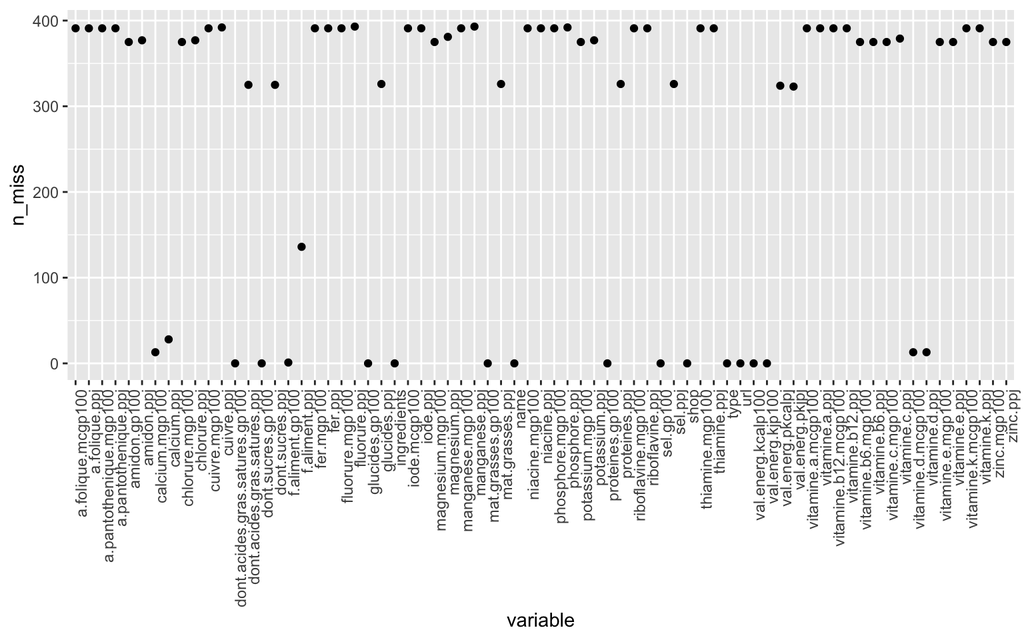

```r
nas <- miss_var_summary(data) %>%
  select("variable", "n_miss")

ggplot(nas) +
  aes(y=n_miss, x=variable) +
  geom_point() +
  theme(axis.text.x = element_text(angle = 90, hjust=1))
```

Overall 58 variables have missing values, out of which 53 have more than 30 missing values. I would like to find a way of replacing them instead of dropping observations or variables. In order to do so I’ll work on missing values for each variable separately while performing exploratory analysis.

### Save the cleaned file

To finish I save the cleaned data into a file.

```r
write.csv2(data, file="DATA/auchan_cleaned.csv", row.names=FALSE)
```